# IODS course project

# Longitudinal data

Read libraries

```r
library(MASS)
library(tidyverse)
```

```r
library(ggplot2)
library(corrplot)
library(knitr)
library(GGally)
library(sjPlot)
library(effects)
library(carData)
library(FactoMineR)
library(lme4)
```

In this exercise, we use BPRSL and RATS data sets, which are in long form.

BPRS describes Brief psychiatric rating scale that is measured before treatment and the following 8 weeks. There are in total 40 participants and two treatment groups (20 participants in each group). All the participants are males.The data frame has in total 360 observations and 5 variables.

RATS data describes results from a nutrition study. The data contains three groups of rats who have different diets.  
There are in total 176 rows obsercations and 5 variables.

```r
# Read the data sets

BPRS <- read.table("C:/LocalData/kpuukko/IODS-project/data/BPRSL.txt", sep="\t")
RATS <- read.table("C:/LocalData/kpuukko/IODS-project/data/RATSL.txt", sep="\t")

#Explore the structure of the data and check summaries

dim(BPRS)
```

```
## [1] 360   5
```

```r
dim(RATS)
```

```
## [1] 176   5
```

```r
summary(BPRS)
```

```
##    treatment      subject         weeks                bprs            week
##  Min.   :1.0   Min.   : 1.00   Length:360         Min.   :18.00   Min.   :0
##  1st Qu.:1.0   1st Qu.: 5.75   Class :character   1st Qu.:27.00   1st Qu.:2
##  Median :1.5   Median :10.50   Mode  :character   Median :35.00   Median :4
##  Mean   :1.5   Mean   :10.50                      Mean   :37.66   Mean   :4
##  3rd Qu.:2.0   3rd Qu.:15.25                      3rd Qu.:43.00   3rd Qu.:6
##  Max.   :2.0   Max.   :20.00                      Max.   :95.00   Max.   :8
```

```r
summary(RATS)
```

```
##        ID            Group           WD                Weight
##  Min.   : 1.00   Min.   :1.00   Length:176         Min.   :225.0
##  1st Qu.: 4.75   1st Qu.:1.00   Class :character   1st Qu.:267.0
##  Median : 8.50   Median :1.50   Mode  :character   Median :344.5
##  Mean   : 8.50   Mean   :1.75                      Mean   :384.5
##  3rd Qu.:12.25   3rd Qu.:2.25                      3rd Qu.:511.2
##  Max.   :16.00   Max.   :3.00                      Max.   :628.0
##       Time
##  Min.   : 1.00
##  1st Qu.:15.00
##  Median :36.00
##  Mean   :33.55
##  3rd Qu.:50.00
##  Max.   :64.00
```

Next, I will convert categorical variables into factors.

```r
BPRS$treatment <- factor(BPRS$treatment)
BPRS$subject <- factor(BPRS$subject)

RATS$ID <- factor(RATS$ID)
RATS$Group <- factor(RATS$Group)
```

First, let’s plot the RATS data. From the plots below, can see that the weight of the individual rats differ clearly between group 1 and groups 2 and 3. The rats in group 1 have lower starting weights and overall more steady weights compared to other groups. Whereas both in groups 2 and 3 rats weight increase. Also it appears that the weight of rats is higher in group 3 than in group 2.

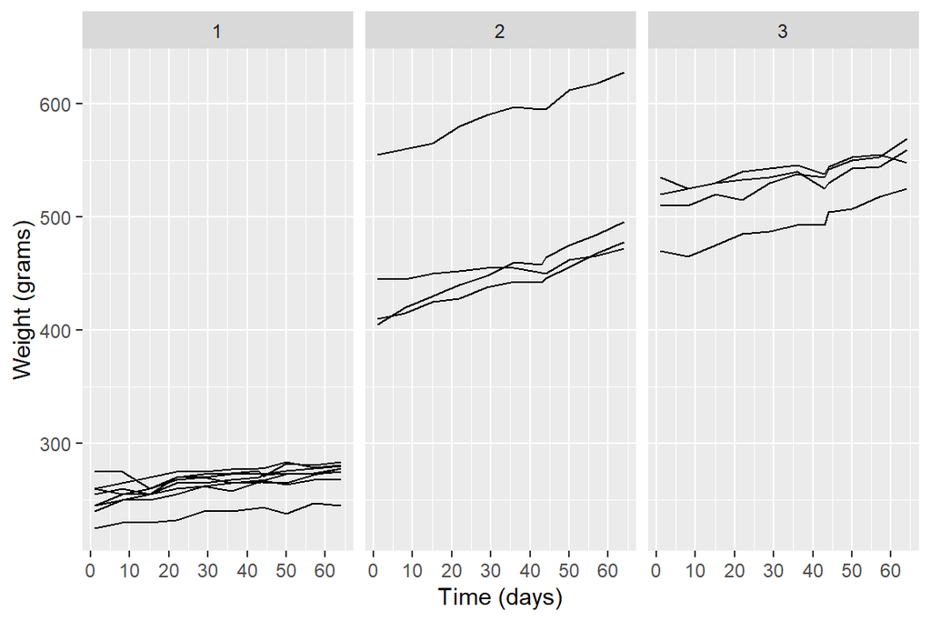

```r
ggplot(RATS, aes(x = Time, y = Weight, group = ID)) +
  geom_line()+
  scale_x_continuous(name = "Time (days)", breaks = seq(0, 60, 10)) +
  scale_y_continuous(name = "Weight (grams)") +
  theme(legend.position = "top") +
  facet_wrap(. ~ Group)
```

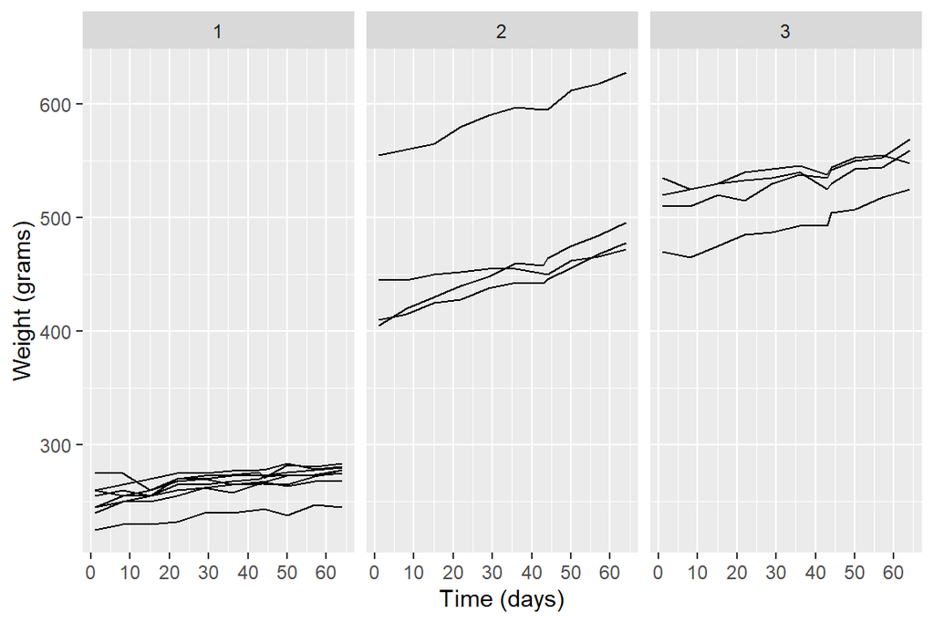

```r
RATS <- RATS %>%
  group_by(Time) %>%
  mutate(stdval = (Weight - mean(Weight))/sd(Weight) ) %>%
  ungroup()

ggplot(RATS, aes(x = Time, y = Weight, group = ID)) +
  geom_line()+
  scale_x_continuous(name = "Time (days)", breaks = seq(0, 60, 10)) +
  scale_y_continuous(name = "Weight (grams)") +
  theme(legend.position = "top") +
  facet_wrap(. ~ Group)
```

Next, I will summarise the measures, the mean and its standard error of the individuals at each time step. The plot below described the group means and the corresponding standard errors (as error bars). The mean weights show again show the same trend: rats in group 3 are the heaviest and in group 1 lightest. Standard errors are largest in group 2, whereas in group 1 very small.

```r
# Summary data with mean and standard error of weight by group and time
n <- RATS$Time %>% unique() %>% length()
n #11
```

```
## [1] 11
```

```r
RATSS <- RATS %>%
  group_by(Group, Time) %>%
  summarise( mean = mean(Weight), se = sd(Weight)/sqrt(n) )%>%
  ungroup()
```

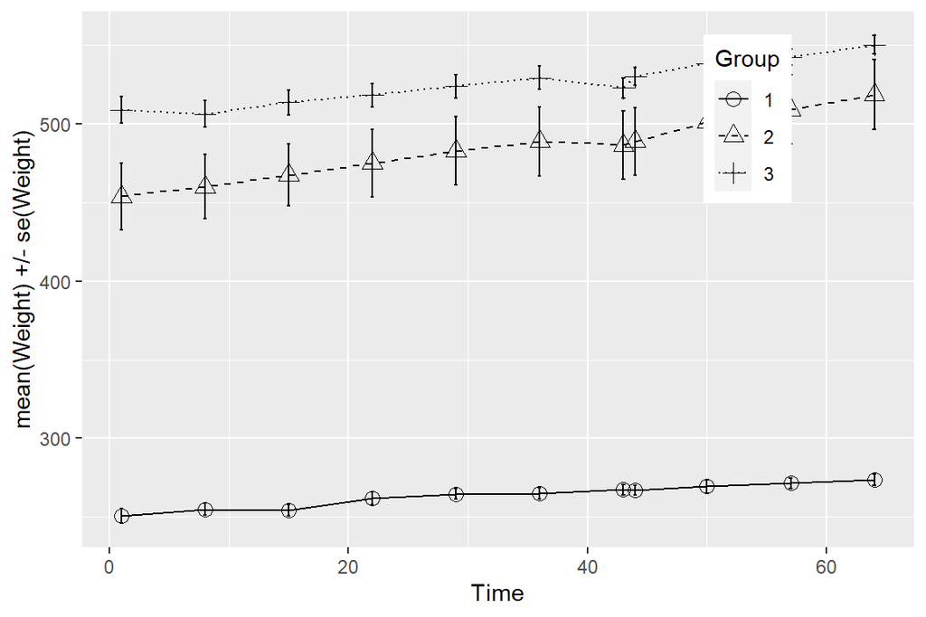

```r
ggplot(RATSS, aes(x = Time, y = mean, linetype = Group, shape = Group)) +
  geom_line() +
  scale_linetype_manual(values = c(1,2,3)) +
  geom_point(size=3) +
  scale_shape_manual(values = c(1,2,3)) +
  geom_errorbar(aes(ymin = mean - se, ymax = mean + se, linetype="1"), width=0.3) +
  theme(legend.position = c(0.8,0.8)) +
  scale_y_continuous(name = "mean(Weight) +/- se(Weight)")
```

```r
RATSID <- RATS %>%
  group_by(Group, ID) %>%
  summarise( mean=mean(Weight) ) %>%
  ungroup()
```